# scDNA: R package for DNA+protein single cell DNA sequencing analysis

Bowman RL

8/15/2022

Start off by loading the scDNA package, and pointing the system to a h5 of interest. For speed purposes, I strongly suggest you have the file local as opposed to on the server. We have hosted the an example h5 on google drive for your convenience. The h5 file will be placed in your home directory, for this tutorial

```r
library(scDNA)
library(googledrive)
drive_download(
  file="https://drive.google.com/file/d/1cy_9AZl3I9hT0RhdhQQZkI0ervM8EPeZ/view?usp=drive_link",
  path = "~/Sample1962.dna+protein.h5",
  overwrite = TRUE
)
```

[output not shown]

```r
file<- "~/Sample1962.dna+protein.h5"
```

```r
NGT<-read_tapestri_h5_NGT(file,
                          VAF_cutoff = 0.05,
                          GT_cutoff = 10 )
```

The next step is to filter out genotypes which are low quality based on read depth (DP), genotype quality score (GQ), or inappropriate allele frequencies (AF). For the AF parameter, we assume that a heterozygous call needs to posses an allele frequency between 20-80%.

```r
filtered_NGT<-quality_filter_NGT(file=file,
                                 NGT=NGT,
                                 DP_cut=10,
                                 AF_cut=20,
                                 GQ_cut=20)
```

These data.frames will possess the same number of variants and cells, but the ‘filtered_NGT’ data.frame will contain many more NAs. The ‘filtered_NGT’ is transposed for downstream processing and more efficient computation.

```r
#Dimensions
print(dim(NGT))
```

```
#> [1]    48 10602
```

```r
print(dim(filtered_NGT))
```

```
#> [1] 10602    49
```

```r
#Total number of NAs
print(table(is.na(NGT)))
```

```
#>
#>  FALSE   TRUE
#> 440220  68676
```

```r
print(table(is.na(filtered_NGT)))
```

```
#>
#>  FALSE   TRUE
#> 276455 243043
```

Now that we have our filtered NGT matrix, we can go through and annotate variants of interest. Here I have constructed a manually curated ‘annotation_key.csv’ file containing ccds_id’s for each gene to denote the transcript of interest. I also made a limited txDB object for these genes so we do not need to query the entire genome. This expedites processing time. Future updates will show the details for constructing your own.

```r
library(VariantAnnotation)
library(GenomicRanges)
library(TxDb.Hsapiens.UCSC.hg19.knownGene)
library(magrittr)
library(AnnotationDbi)
library(dplyr)
library(pals)
library(tidyr)
library(tidyverse)
annotation_key<-read.csv("annotation_key.csv")
hg19refseq_txdb<-loadDb("hg19refseq_txdb.sqlite")
banned<-read.csv("banned_list.csv")[,1]

annotation_key%<>%inner_join(VariantAnnotation::select(hg19refseq_txdb,
                                    keys=annotation_key$ccds_id,
                                    columns=c("TXID","TXNAME"),
                                    keytype = "TXNAME"),
                             by=c("ccds_id"="TXNAME"))%>%
                  mutate(TXID=as.character(TXID))
```

Now we can use the ‘annotate_variants’ function from the ‘scDNA’ package.

```r
final_mutation_info<- annotate_variants(file=file,
                             annotation_key=annotation_key,
                             txdb=hg19refseq_txdb,
                             banned=banned,
                             NGT=filtered_NGT)

final_mutation_info%>%
                arrange(desc(Bulk_VAF))%>%
                dplyr::select(AA,Bulk_VAF,GT_call_rate,id)%>%
                head(n=10)
```

```
#>                 AA Bulk_VAF GT_call_rate                     id
#> 1       ATM.N1983S 99.99446    85.087719    chr11:108183167:A/G
#> 2    TP53.intronic 99.96448    66.383701      chr17:7578115:T/C
#> 3      ASXL1.L815P 99.96099    84.616110     chr20:31022959:T/C
#> 4    SETBP1.S1275S 99.94951    65.383890     chr18:42533130:A/G
#> 5  DNMT3A.intronic 99.65726    46.783626      chr2:25463483:G/A
#> 6   SRSF2.intronic 99.54128     5.140540     chr17:74733099:G/A
#> 7       SRSF2.D48D 99.54128     5.140540     chr17:74733099:G/A
#> 8   STAG2.intronic 99.39153    17.826825     chrX:123197557:T/C
#> 9      STAG2.L204L 53.84615     0.980947     chrX:123179163:T/G
#> 10   FLT3.intronic 50.98639    75.542350 chr13:28602226:AAGAG/A
```

The above annotates all mutations greater than bulk VAF cutoff established when reading in the first NGT file. This bulk VAF is computed in cells for which the variant was successfully genotyped, so if a successful genotype is only found in 10 cells, you can get a VAF of 20% with only 2 mutant cells. Hence the ‘GT_call_rate’ is critical to keep in mind here.

From here, we can go in two directions here. For samples selected with specific variants of interest, we can pick them out precisely. For a “discovery mode” we can pass a reasonable set of rules. We can also use these in concert for a hybrid approach.

Here we will search for specific variants we expect to find this sample based on bulk sequencing.

```r
required_variants<- final_mutation_info%>%
                        dplyr::filter(grepl("RAS|NPM1.2|TET",AA))%>%
                        dplyr::filter(Bulk_VAF>2&GT_call_rate>15)%>%
                        dplyr::filter(CONSEQUENCE%in%c("nonsynonymous","frameshift","nonsense"))%>%
                        dplyr::select(id,Bulk_VAF,GT_call_rate,AA)%>% #break here to observe full table with mutation information of interest
                        pull(id)
```

We can then ask which cells possess complete genotyping information for these critical variants. We want to retain these cells throughout all future analyses and refer to them as “required_cells”.

```r
required_cells<-filtered_NGT%>%dplyr::select(Cell,tidyselect::all_of(required_variants))%>%
                    dplyr::filter(across(.cols = !Cell,.fns = ~ !is.na(.x)))%>%
                    pull(Cell)
```

What other variants could we also look into without losing too many of these required cells? We might be interested in seeing if there are other variants that are well represented amongst these required variants. We will focus on non-synonymous mutations that are not in introns for this vignette.

```r
coding_variants<- final_mutation_info%>%
                        dplyr::filter(!grepl("intronic",AA))%>%
                        dplyr::filter(CONSEQUENCE!="synonymous")%>%
                        dplyr::filter(GT_call_rate>10)%>%
                        dplyr::filter(Bulk_VAF>0.5)%>%
                        dplyr::select(id,Bulk_VAF,GT_call_rate,AA)%>% #break here to observe full table with mutation information of interest
                        pull(id)

mut_info_annotated<-filtered_NGT%>%
                          pivot_longer(cols=-Cell,names_to="id",values_to = "NGT")%>% #transform length wise
                          dplyr::filter(!is.na(NGT))%>% #remove poor genotyping calls
                          dplyr::filter(id%in%coding_variants)%>% #select variants of interest
                          group_by(id)%>% #split data.frame into groups based on the variants of interest variants
                          summarise(required_cell_ratio = mean(all_of(required_cells)%in%Cell))%>% # calculate the proportion of required cells represnted in successfully genotyped cells for that variant
                          arrange(desc(required_cell_ratio))%>% # order the data.frame, helpful for pltting later
                          inner_join(final_mutation_info)%>% # join with mutation info
                          dplyr::filter(!grepl("intronic",AA))%>%  #removes duplicate transcripts
                          mutate(id=factor(id,levels=c(id)))%>% #helpful for pltting later
                          mutate(AA=factor(AA,levels=c(AA)))%>%  #helpful for pltting later
                          mutate(required=ifelse(id%in%required_variants,"Required","Other"))%>%
                          dplyr::select(id,required_cell_ratio,Bulk_VAF,GT_call_rate,AA,required)
```

Let’s graphically look at these tables for some context

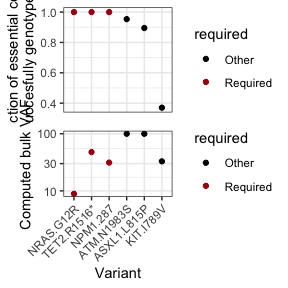

```r
library(ggplot2)
library(RColorBrewer)
library(cowplot)
ggFraction<-ggplot(mut_info_annotated,aes(x=AA,y=required_cell_ratio,color=required))+
              geom_point()+
              theme_bw()+
              labs(y="Fraction of essential cells \n succesfully genotyped")+
              scale_color_manual(values=c("Required"=brewer.pal(5,"Reds")[5],
                                          "Other"="black"))+
              theme(axis.text.x=element_blank(),
                    axis.ticks.x = element_blank(),
                    axis.title.x = element_blank())

ggVAF<-ggplot(mut_info_annotated,aes(x=AA,y=Bulk_VAF,color=required))+
              geom_point()+
              theme_bw()+
              scale_y_log10()+
              labs(x="Variant",y="Computed bulk VAF")+
              scale_color_manual(values=c("Required"=brewer.pal(5,"Reds")[5],
                                          "Other"="black"))+
              theme(axis.text.x=element_text(angle=45,hjust=1,vjust=1))

plot_grid(ggFraction,ggVAF,ncol=1,axis="lr",align="v",rel_heights=c(0.75,1))
```

For this matrix, we can filter out cells that are important to us with the function below.

```r
complete_NGT<- filtered_NGT%>%
                    dplyr::select(Cell,all_of(required_variants))%>%
                    dplyr::filter(Cell%in%required_cells)
print(dim(complete_NGT))
```

```
#> [1] 1743    4
```

```r
print(table(is.na(complete_NGT)))
```

```
#>
#> FALSE
#>  6972
```

There are likely quite a few cells which we can hope to gain information from though, albeit with lower quality information. We can extract those too and mask them. The function “active_NGT_filter” below is written for optimal extraction of meaningful cells from a wide range of variants. Here we will simply restrict the filtering to the exact “required_variants” we are interested in. You can think of the “variants_of_interest” argument below as a universe from which we could sample.

```r
maximal_NGT<-scDNA::active_NGT_filter(filtered_NGT,
                                  variants_of_interest=required_variants,
                                  required_variants=required_variants,
                                  required_cells=required_cells,
                                  variant_score_cutoff=0.4,
                                  cell_score_cutoff=0.4,
                                  greedy_scalar=0.005)
```

In a different setting we might have included new variants than just our required ones, and as such we would want to update the variant information. This is achieved below.

```r
final_variant_info <- mut_info_annotated%>%
                                dplyr::filter(id%in%(all_of(colnames(maximal_NGT))))%>%                       dplyr::select(id,required_cell_ratio,Bulk_VAF,GT_call_rate,AA)%>%
                                arrange(desc(Bulk_VAF))
```

We now have our complete_NGT (full of required_cells only), and our maximal_NGT where we may have low quality information. Using the function below we can fill in the NA’s in the maximal_NGT with that low quality info, and flag cells as either “Complete” or “Other” for downstream processing.

```r
final_NGT<-generate_lowQC_matrix(file=file,
                                 complete_NGT=complete_NGT,
                                 NGT_to_fill=maximal_NGT)
```

Now we want to enumerate how many clones are present by identifying the abundance of genetically identical cells. We use the following clone naming convention, where left to right reads in the order of bulk VAF, and each genotype is separated by an underscore (“_“). So a clone 1_0_1 would be heterozygous for the 1st and 3rd most abundant mutations, and WT for the 2nd most abundant. This function returns a list with three slots: Clones, NGT, and Architecture. The replicates argument is used to determine how many rounds of resampling should be performed to establish a 95% confidence interval on the abundance of a particular clone.

```r
final_sample_summary<-enumerate_clones(NGT=final_NGT,
                                       variant_metadata=final_variant_info,
                                       replicates = 500)
```

With the clones enumerated, we can now aggregate the median read depth, genotype quality and allele dropout per clone. We overwrite this into the ‘Clones’ slot into the final_sample_summary object.

```r
final_sample_summary$Clones<-clone_QC(final_sample_summary, file)
```

We can now look at a clonograph of the data

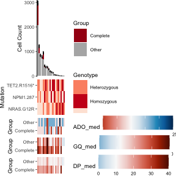

```r
clonograph(final_sample_summary)
```

Based on this we can also select clones of interest either based on QC metrics, or by passing a string of clone names to the ‘select exact’ argument. If you use the ‘select_exact’ argument, then the QC metrics willbe ignored.

```r
final_sample_summary_subset<-select_clones(final_sample_summary,
                                            ADO_cut=0.10,
                                            GQ_cut=30,
                                            DP_cut=10,
                                            select_exact=FALSE)
```

Here we see a cleaned up clongraph.

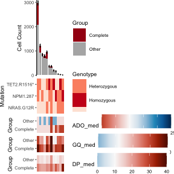

```r
clonograph(final_sample_summary_subset)
```

We can also strip out the “Other” cells and only focus on those with complete genotype data. As of now, we lose the confidence intervals when we subset this way.

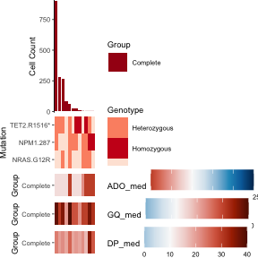

```r
clonograph(final_sample_summary_subset,complete_only = TRUE)
```

Now we will demonstrate how to export the protein data to Seurat for clustering, and producing a UMAP. We also demonstrate our wrapper to normalize protein data with either CLR (base Seurat) or dsb if you have IGg controls. Coming soon, our own normalization method for protein information! Stay tuned!

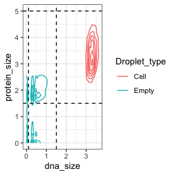

```r
protein_mat_final<-read_tapestri_h5_protein(file=file)%>%
                          dplyr::filter(Cell%in%final_sample_summary_subset$NGT$Cell)

metadata<- extract_droplet_size(file,
                                final_sample_summary=final_sample_summary_subset)

# Try changing bins=1000 to see overlap empty droplets and real ones
ggplot(metadata, aes(x = dna_size, y = protein_size,color=Droplet_type )) +
                  theme_bw() +
                  geom_density_2d(bins=10)+
                  geom_hline(yintercept =c(1.5,5),lty=2)+
                  geom_vline(xintercept =c(0.1,1.5),lty=2)
```

After obtaining the protein matrix, we now want to extract background cells and normalize the protein. Both strategies to normalize the data are shown below.

```r
library(dsb)
library(Seurat)
background_droplets<-metadata%>%
                          dplyr::filter(Droplet_type=="Empty")%>%
                          dplyr::filter(dna_size<1.5&dna_size>0.15)%>%
                          pull(Cell)
source("~/Lab/Core/scDNA_dev/scDNA-namwob44-install-patch/R/normalize_protein_data.R")
normalized_protein_mat<-normalize_protein_data(file=file,
                                         metadata=metadata,
                                         protein_mat=protein_mat_final,
                                         method="dsb",
                                         detect_IgG=TRUE,
                                         background_droplets=background_droplets)
```

```
#> [1] "correcting ambient protein background noise"
#> [1] "fitting models to each cell for dsb technical component and removing cell to cell technical noise"
```

```r
normalized_protein_mat<-normalize_protein_data(file=file,
                                          metadata=metadata,
                                           protein_mat=protein_mat_final,
                                           method="CLR",
                                           detect_IgG=FALSE,
                                          background_droplets=background_droplets)

final_metadata<- metadata%>%
                        dplyr::filter(Cell%in%colnames(normalized_protein_mat))%>%
                        dplyr::arrange(match(Cell,colnames(normalized_protein_mat)))
```

Now we want to load in our data into Seurat. Keep in mind which normalization method for protein was used above. Comment out the one you do not want to use (or let it use CLR as it will currently overwrite the dsb one). Below follows the standard Seurat implementation where you apply nearest neighbor search, generate clusters, and build a UMAP. Afterwards, are some examples of further data exploration and plots to analyze your results.

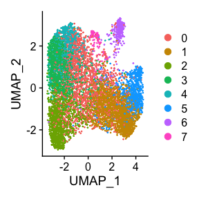

```r
s <- CreateSeuratObject(counts=normalized_protein_mat,
                        assay="Protein")

s <- AddMetaData(object = s,
                 metadata = list("Clone"=final_metadata%>%pull("Clone"),
                                  "dna_size"=final_metadata%>%pull("dna_size"),
                                  "amplicons"=final_metadata%>%pull("amplicons"),
                                  "protein_size"=final_metadata%>%pull("protein_size"),
                                  "Group"=final_metadata%>%pull("Group"),
                                  "Tet2"=final_metadata%>%pull("chr4:106196213:C/T"),
                                  "Npm1"=final_metadata%>%pull('chr5:170837543:C/CTCTG'),
                                  "Nras"=final_metadata%>%pull('chr1:115258748:C/G')))

# cluster and run umap (based directly on dsb normalized values without isotype controls)
prots <- rownames(s@assays$Protein@data)[2:42]
s <- FindNeighbors(object = s, dims = NULL, assay = 'Protein',
                  features = prots, k.param = 30, verbose = FALSE)

# direct graph clustering
s <- FindClusters(object = s, resolution = 1, algorithm = 3, graph.name = 'Protein_nn', verbose = FALSE)

# umap for visualization only; (this is optional)
s = RunUMAP(object = s, assay = "Protein", features = prots, seed.use = 1990,
            min.dist = 0.2, n.neighbors = 50, verbose = FALSE)

DimPlot(s,reduction = "umap")
```

```r
all.markers <-FindAllMarkers(s,test.use="roc")

FindMarkers(s,ident.1="1",ident.2="2")
```

```
#>               p_val avg_log2FC pct.1 pct.2     p_val_adj
#> CD138  0.000000e+00  0.8259786 0.999 0.971  0.000000e+00
#> CD30   0.000000e+00  0.7109097 0.999 0.980  0.000000e+00
#> CD25  1.647133e-290  0.8331344 0.992 0.900 7.576810e-289
#> CD44  5.536769e-276 -0.6754118 0.959 0.986 2.546914e-274
#> CD14  3.746883e-226 -1.0403720 0.791 0.913 1.723566e-224
#> CD83  5.404458e-205  0.5049880 0.995 0.970 2.486051e-203
#> CD117 2.637640e-199  0.6821579 0.969 0.843 1.213315e-197
#> CD45  2.063253e-175 -0.3385744 0.988 0.991 9.490963e-174
#> CD11b 6.125745e-165 -0.6308921 0.911 0.944 2.817843e-163
#> CD33  1.182413e-158 -0.5687256 0.931 0.950 5.439100e-157
#> CD64  1.100171e-137 -0.5678839 0.945 0.950 5.060785e-136
#> CD69  2.913336e-106  0.4570342 0.967 0.874 1.340135e-104
#> CD56   1.013408e-88 -0.2529583 0.994 0.987  4.661678e-87
#> CD22   2.330303e-78  0.4433092 0.849 0.699  1.071939e-76
#> CD90   2.373368e-74  0.4240668 0.820 0.642  1.091749e-72
#> CD163  2.774188e-70 -0.3309039 0.972 0.967  1.276126e-68
#> IgG2a  1.673944e-66  0.3780523 0.847 0.687  7.700143e-65
#> CD34   2.495511e-64  0.3685614 0.953 0.865  1.147935e-62
#> CD19   1.830319e-55  0.2969909 0.634 0.407  8.419468e-54
#> CD123  8.899302e-55 -0.3018330 0.962 0.964  4.093679e-53
#> CD11c  1.466400e-47 -0.6090207 0.523 0.611  6.745440e-46
#> CD303  1.210624e-45  0.3098589 0.832 0.700  5.568873e-44
#> CD13   7.150130e-37  0.2546696 0.981 0.905  3.289060e-35
#> CD2    5.154389e-12 -0.3836469 0.378 0.420  2.371019e-10
```

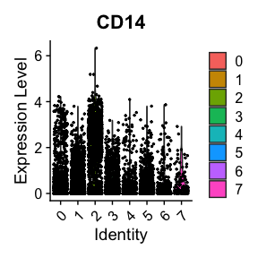

```r
VlnPlot(s,features=c("CD14"),  pt.size = 0.5)
```

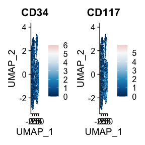

```r
Idents(object = s) <- "seurat_clusters"


FeaturePlot(s,features = c("CD34","CD117"),keep.scale = "feature")&
            colorspace::scale_color_continuous_divergingx(palette = 'RdBu',
                                                          mid = 5,
                                                          rev=TRUE,
                                                          na.value = "grey80")
```

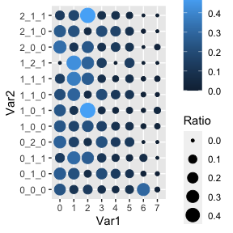

```r
data_out<-table(s@meta.data$Protein_nn_res.1,s@meta.data$Clone)%>%
                          data.frame%>%
                          group_by(Var2)%>%
                          mutate(Ratio=Freq/sum(Freq))
ggplot(data_out,aes(x=Var1,y=Var2,size=Ratio,color=Ratio))+geom_point()
```

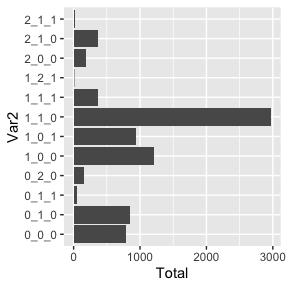

```r
ggplot(data_out%>%summarise(Total=sum(Freq)),aes(x=Total,y=Var2))+geom_col()
```

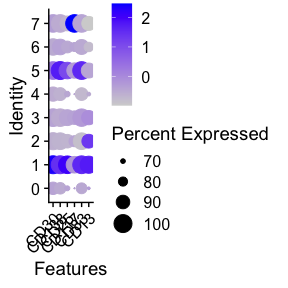

```r
DotPlot(s, features = c(all.markers%>%dplyr::filter(cluster=="1")%>%pull(gene))[1:8]) + RotatedAxis()
```

[figure not shown]

```r
RidgePlot(s,features= c("CD117","CD14","CD11b","CD34","CD138"))
```

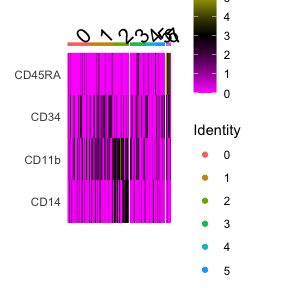

```r
DoHeatmap(s,slot = "counts", features = c("CD45RA","CD34","CD11b","CD14"))
```

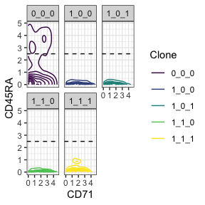

```r
# make results dataframe
d = cbind(s@meta.data, as.data.frame(t(s@assays$Protein@data)), s@reductions$umap@cell.embeddings)

# calculate the median protein expression separately for each cluster
adt_plot = d %>%
  dplyr::group_by(Protein_nn_res.1) %>%
  dplyr::summarize_at(.vars = prots, .funs = median) %>%
  tibble::remove_rownames() %>%
  tibble::column_to_rownames("Protein_nn_res.1")


ggplot(d%>%
          dplyr::filter(Clone%in%c("0_0_0","1_0_0","1_1_0","1_0_1","1_1_1")),
          aes(x =  `CD71`,y = CD45RA,color=Clone)) +
                  theme_bw() +
                  facet_wrap(~Clone)+
                  geom_density_2d(contour_var = "ndensity")+
                #  geom_point()+
                  scale_color_viridis_d() +
                  geom_hline(yintercept =c(2.5),lty=2)+
                  geom_vline(xintercept =c(),lty=2)
```

Stay tuned for the following updates and things we are actively working on next: Near term: 1. FCS export 2. Finalizing trajectory optimization 3. Finalizing cohort characterization 4. Creating your own TxDB tutorial Ongoing investigation: 1. Improved cell identification. 2. A new filtering and normalization for protein data. 3. Diagnostics on your assays. 4. Improvements to the MDP and RL: a. Introducing safe RL through risk-sensitivity  
b. introducing probabilistic states and actions c. improvements in performance by changing to a sparse representation d. Improved trajectory analysis and path finding. i. longest pathway to mutation ii. free energy principle to find shortest path. e. improvements to MDP formalization for improved accuracy and efficiency. f. Improvements to RL algorithm to speed up the learned model. 5. Updating presentation of figures.